# ExploRatory Data Analysis Notebook

## Loading packages

In this notebook we will make use of the *tidyverse* package which comes with a lot of convenient functions for doing data analysis. In particular, we will use the *dplyr* package for data wrangling, *forcats* package to easily handle categorical data, and the *ggplot2* package to display our data.

- [dplyr cheatsheet](https://www.rstudio.com/wp-content/uploads/2015/02/data-wrangling-cheatsheet.pdf)
- [forcasts demo](http://forcats.tidyverse.org/)
- [ggplot2 cheatsheet](https://www.rstudio.com/wp-content/uploads/2015/03/ggplot2-cheatsheet.pdf)

```r
library(tidyverse)
library(forcats)
```

## Piping Commands

A key idea in Tidyverse is the that of piping. The tidyverse achieves this using the [magrittr](https://cran.r-project.org/web/packages/magrittr/vignettes/magrittr.html) package.

The following example of code shows a sequence of commands using nested function calls.

```
summarize(group_by(arrange(mutate(tb, options ...), options ...), options ...), options ...)
```

Piping makes these same commands easier to understand.

```
tb %>%
  mutate(options ...) %>%
  arrange(options ...) %>%
  group_by(options ...) %>%
  summarize(options ...)
```

## Loading the data

Whenever you want to do something new in R, just google what you want to do; there is a good chance there is a function out there that does what you want. In this case we used the `read_csv` function to load the data. We used the `n_max` parameter to read in only the first 1000 rows.

```r
tb <- read_csv('properties_2016.csv', n_max=1000)
```

## Exploring the Data

The first thing we can do is take a look at the data.

```r
tb %>% head(10)
```

| parcelid | airconditioningtypeid | architecturalstyletypeid | basementsqft | bathroomcnt | bedroomcnt | buildingclasstypeid | buildingqualitytypeid | calculatedbathnbr | decktypeid | ⋯ | numberofstories | fireplaceflag | structuretaxvaluedollarcnt | taxvaluedollarcnt | assessmentyear | landtaxvaluedollarcnt | taxamount | taxdelinquencyflag | taxdelinquencyyear | censustractandblock |
| --- | --- | --- | --- | --- | --- | --- | --- | --- | --- | --- | --- | --- | --- | --- | --- | --- | --- | --- | --- | --- |
| 10754147 | NA | NA | NA | 0 | 0 | NA | NA | NA | NA | ⋯ | NA | NA | NA | 9 | 2015 | 9 | NA | NA | NA | NA |
| 10759547 | NA | NA | NA | 0 | 0 | NA | NA | NA | NA | ⋯ | NA | NA | NA | 27516 | 2015 | 27516 | NA | NA | NA | NA |
| 10843547 | NA | NA | NA | 0 | 0 | NA | NA | NA | NA | ⋯ | NA | NA | 650756 | 1413387 | 2015 | 762631 | 20800.37 | NA | NA | NA |
| 10859147 | NA | NA | NA | 0 | 0 | 3 | 7 | NA | NA | ⋯ | 1 | NA | 571346 | 1156834 | 2015 | 585488 | 14557.57 | NA | NA | NA |
| 10879947 | NA | NA | NA | 0 | 0 | 4 | NA | NA | NA | ⋯ | NA | NA | 193796 | 433491 | 2015 | 239695 | 5725.17 | NA | NA | NA |
| 10898347 | NA | NA | NA | 0 | 0 | 4 | 7 | NA | NA | ⋯ | 1 | NA | 176383 | 283315 | 2015 | 106932 | 3661.28 | NA | NA | NA |
| 10933547 | NA | NA | NA | 0 | 0 | NA | NA | NA | NA | ⋯ | NA | NA | 397945 | 554573 | 2015 | 156628 | 6773.34 | NA | NA | NA |
| 10940747 | NA | NA | NA | 0 | 0 | NA | NA | NA | NA | ⋯ | 1 | NA | 101998 | 688486 | 2015 | 586488 | 7857.84 | NA | NA | NA |
| 10954547 | NA | NA | NA | 0 | 0 | NA | NA | NA | NA | ⋯ | NA | NA | NA | 9 | 2015 | 9 | NA | NA | NA | NA |
| 10976347 | NA | NA | NA | 0 | 0 | 3 | 7 | NA | NA | ⋯ | 1 | NA | 218440 | 261201 | 2015 | 42761 | 4054.76 | NA | NA | NA |

We note that there are a lot of NA values. Let's do something interesting with them by first counting the number of NAs in each column and then plotting the results.

There is more than one way to count the number of NA values; we show a few ways below.

```r
sum(is.na(tb$latitude)) # the base R way
tb$latitude %>% is.na %>% sum # using piping
```

0

0

We can use the `summarize_all` function from the *dplyr* package to apply a function to every columnn of a data.frame (tibble). For example, below we count the number of NAs in each column.

```r
na_nums <- tb %>% summarize_all(. %>% is.na %>% sum)
na_nums
```

| parcelid | airconditioningtypeid | architecturalstyletypeid | basementsqft | bathroomcnt | bedroomcnt | buildingclasstypeid | buildingqualitytypeid | calculatedbathnbr | decktypeid | ⋯ | numberofstories | fireplaceflag | structuretaxvaluedollarcnt | taxvaluedollarcnt | assessmentyear | landtaxvaluedollarcnt | taxamount | taxdelinquencyflag | taxdelinquencyyear | censustractandblock |
| --- | --- | --- | --- | --- | --- | --- | --- | --- | --- | --- | --- | --- | --- | --- | --- | --- | --- | --- | --- | --- |
| 0 | 987 | 1000 | 994 | 0 | 0 | 939 | 940 | 289 | 943 | ⋯ | 278 | 1000 | 163 | 132 | 0 | 136 | 31 | 990 | 990 | 295 |

## Visualizing the Data

Now that we have our counts, let's visualize them. Below we create a tibble of the data to plot.

```r
ggdat <- tibble(
    col_name = names(na_nums),
    num_na = as.numeric(na_nums)
)
ggdat %>% head(10)
```

| col_name | num_na |
| --- | --- |
| parcelid | 0 |
| airconditioningtypeid | 987 |
| architecturalstyletypeid | 1000 |
| basementsqft | 994 |
| bathroomcnt | 0 |
| bedroomcnt | 0 |
| buildingclasstypeid | 939 |
| buildingqualitytypeid | 940 |
| calculatedbathnbr | 289 |
| decktypeid | 943 |

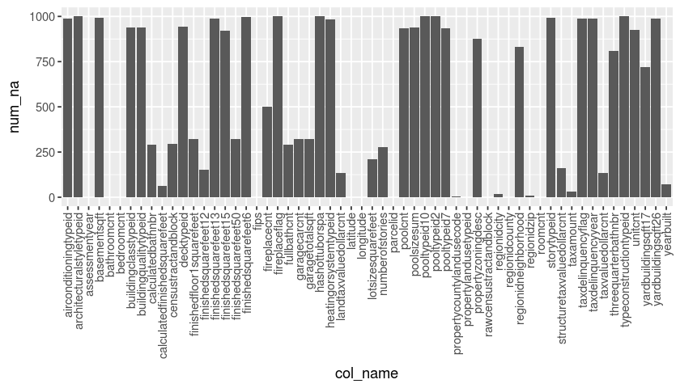

```r
options(repr.plot.height=4)
ggplot(ggdat) +
  geom_col(aes(x=col_name, y=num_na)) +
  theme(axis.text.x=element_text(angle=90, hjust=1, vjust=0.5))
```

Notice that the values on the x-axis are in alphabetical order. We can change that by first sorting the data in the desired format and then converting the `col_name` column into an ordered factor.

```r
ggdat_ordered <- tibble(
    col_name = names(na_nums),
    num_na = as.numeric(na_nums)
) %>% arrange(-num_na) %>% mutate(col_name=fct_inorder(col_name))
ggdat_ordered %>% head(10)
```

| col_name | num_na |
| --- | --- |
| architecturalstyletypeid | 1000 |
| hashottuborspa | 1000 |
| pooltypeid10 | 1000 |
| pooltypeid2 | 1000 |
| typeconstructiontypeid | 1000 |
| fireplaceflag | 1000 |
| finishedsquarefeet6 | 999 |
| basementsqft | 994 |
| storytypeid | 994 |
| taxdelinquencyflag | 990 |

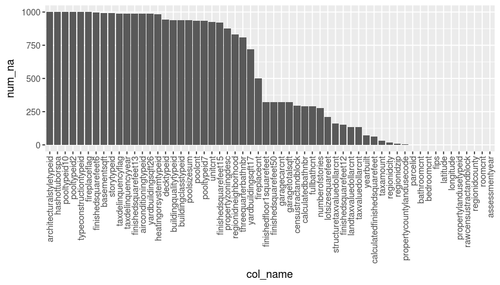

```r
ggplot(ggdat_ordered) +
  geom_col(aes(x=col_name, y=num_na)) +
  theme(axis.text.x=element_text(angle=90, hjust=1, vjust=0.5))
```